# Final assignment

Frida Gyllenberg

18 Dec 2017

## Abstract

The aim of this final assingement was to achieve in-depth learning of the skills I learned during the Open Data Science Course at the University of Helsinki, fall 2017. I investigated the relationship between age, gender, and some variables describing students attitudes and learning habits on exam points. Of this explanatory variables, only Attitude and Strategic learning showed a significant positive relationship with points higher than the median score.

## Hypothesis

For the final assingment I chose to use the Learning2014 data set and Logistic regression. I am intrested in looking at which explanatory ariables that associates with the outcome of having hifgher points than the median points.

#### Data wrangling

The data wrangling is computed in an R Script, wich can be found at https://github.com/fripa/IODS-final/blob/master/data_wrangling.R The data wranlging includes computing some explanatory variables by joining together variables from the same dimensions, and creating a binary outcome variable needed for the logistic regression.

## Logistic regression

Logistic regression is used to assess the relationship between a set of discrete or continuous explanatory variables and a binary outcome variable, where the observations should be independent of each other. As the outcome variable is binary, we need to transform it to be able to assign an appropriate equation, hence we used the log odds of the outcome. The log odds of the outcome can be written as “ln(p/1- p)” and the logistic regression equation as “α + β1*X1 + β2*X2+ β3*X3…" depending on how many explanatory variables are included in the model.

Examples of a study question where logistic regression is usuful is e.g. how smoking is related to lung cancer (equation: ln (odds of lung cancer) = α + β1*(smoking, yes/no)), which we can further adjust by age (ln (odds of lung cancer) = α + β1*(smoking, yes/no) + β2*(age)).

The results are presented as odds ratios, i.e the odds of lung cancer given that the person smokes divided by the odds of lung cancer given that the person does not smoke. Basic algebra then gives us that the exponate of the beta estimate equals the odds ratio as

OR = (e ^(α+β*smoking=1) / (e ^(α+β*smoking=0)) = (e ^α* e ^(β*smoking=1) / (e ^α* e ^(β*smoking=0) = e ^(β*smoking=1)

#### Major assumption of Logistic regression

- The dependent variable should be binary
- There should be no outliers in the data
- There should be no high correlations (multicollinearity) among the predictors.
- The observations are independent

## The data

The data I used is a subset from the Learning2014 data set. The original data was gathered by Kimmo Vehkalahti during the course “Introduction to Social Statistics”, during fall 2014. It consists of 60 variables, of which the first 56 are qeastions answered by the students. Background variables consists of Age and Gender, and the data set also includes the Final exam points and a computed Attitude variable, that is a sum variable of the 10 questions concerning the students attitude towards statistics.

For this assignement I have merged data from the individual questions into the dimension-variables of surface learnign, deep learning and strategic learning, and dropped the individual questions. Also, I have created a binary variable of Points, where I have defined points above the median as “high” and points below median as “low”.

The data set thus have 8 variables of 166 observations, i.e. students. There are 110 females and 56 males, their mean age is 25.5 and the mean score in the exam is 22.7. The proportion of males having high points is slightly larger than females having a high score. Let us look closer on this relationship.

```r
#reading in data
learn <- readRDS("learn.Rds")
#dimensions and summary
learn %>% glimpse
```

```
## Observations: 166
## Variables: 8
## $ gender      <fctr> F, M, F, M, M, F, M, F, M, F, M, F, F, F, M, F, F...
## $ Age         <int> 53, 55, 49, 53, 49, 38, 50, 37, 37, 42, 37, 34, 34...
## $ Attitude    <int> 37, 31, 25, 35, 37, 38, 35, 29, 38, 21, 39, 38, 24...
## $ deep        <dbl> 3.583333, 2.916667, 3.500000, 3.500000, 3.666667, ...
## $ stra        <dbl> 3.375, 2.750, 3.625, 3.125, 3.625, 3.625, 2.250, 4...
## $ surf        <dbl> 2.583333, 3.166667, 2.250000, 2.250000, 2.833333, ...
## $ Points      <int> 25, 12, 24, 10, 22, 21, 21, 31, 24, 26, 31, 31, 23...
## $ high_points <lgl> TRUE, FALSE, TRUE, FALSE, FALSE, FALSE, FALSE, TRU...
```

```r
learn %>% summary
```

```
##  gender       Age           Attitude          deep            stra
##  F:110   Min.   :17.00   Min.   :14.00   Min.   :1.583   Min.   :1.250
##  M: 56   1st Qu.:21.00   1st Qu.:26.00   1st Qu.:3.333   1st Qu.:2.625
##          Median :22.00   Median :32.00   Median :3.667   Median :3.188
##          Mean   :25.51   Mean   :31.43   Mean   :3.680   Mean   :3.121
##          3rd Qu.:27.00   3rd Qu.:37.00   3rd Qu.:4.083   3rd Qu.:3.625
##          Max.   :55.00   Max.   :50.00   Max.   :4.917   Max.   :5.000
##       surf           Points      high_points
##  Min.   :1.583   Min.   : 7.00   Mode :logical
##  1st Qu.:2.417   1st Qu.:19.00   FALSE:91
##  Median :2.833   Median :23.00   TRUE :75
##  Mean   :2.787   Mean   :22.72   NA's :0
##  3rd Qu.:3.167   3rd Qu.:27.75
##  Max.   :4.333   Max.   :33.00
```

#### Graphical overview, excluding the binary high_points variable

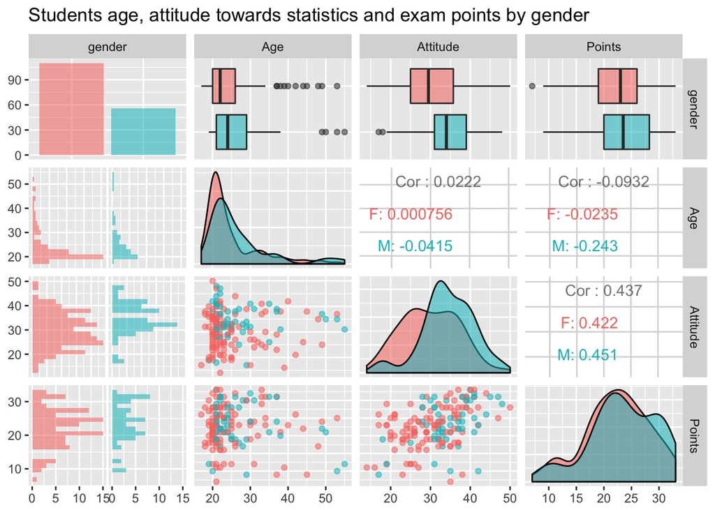

```r
p <- ggpairs(learn,
             columns = c(1:3, 7),
             title ="Students age, attitude towards statistics and exam points by gender",
             mapping = aes(col=gender, alpha=0.3),
             lower = list(combo = wrap("facethist", bins = 20)))
p
```

From this graphical overview by sex (female=pink) it seems that Attitude towards statistics has a strong positive correlation with exam points of euqual size in both makes and females. Age has a slight negative correlation to exam points, and this correlation is stronger among males.  
####cross-tabulation of high points by gender

```r
table(high_points=learn$high_points, gender=learn$gender)
```

```
##            gender
## high_points  F  M
##       FALSE 63 28
##       TRUE  47 28
```

Of the 110 females, 47 (i.e. 43 %) scored above the median, while 50 % of males scored above the median points.

## Analysis

For the analysis, I used logistic regression to assess the relationship between gender; age; attitude towards statistics; three different learning dimensions described as strategic, surface and deep learning, and points in the final exam.

```r
m <- glm(learn$high_points ~ learn$Age, family = "binomial")

summary(m)
```

```
##
## Call:
## glm(formula = learn$high_points ~ learn$Age, family = "binomial")
##
## Deviance Residuals:
##    Min      1Q  Median      3Q     Max
## -1.108  -1.102  -1.075   1.255   1.307
##
## Coefficients:
##              Estimate Std. Error z value Pr(>|z|)
## (Intercept) -0.095773   0.538212  -0.178    0.859
## learn$Age   -0.003827   0.020211  -0.189    0.850
##
## (Dispersion parameter for binomial family taken to be 1)
##
##     Null deviance: 228.58  on 165  degrees of freedom
## Residual deviance: 228.54  on 164  degrees of freedom
## AIC: 232.54
##
## Number of Fisher Scoring iterations: 3
```

```r
OR<-coef(m) %>% exp
CI<-confint(m) %>% exp
cbind(OR,CI)
```

```
##                    OR     2.5 %   97.5 %
## (Intercept) 0.9086701 0.3164135 2.650933
## learn$Age   0.9961799 0.9564936 1.036356
```

```r
m2 <- glm(learn$high_points ~ learn$Age + learn$gender, family = "binomial")

summary(m2)
```

```
##
## Call:
## glm(formula = learn$high_points ~ learn$Age + learn$gender, family = "binomial")
##
## Deviance Residuals:
##    Min      1Q  Median      3Q     Max
## -1.198  -1.068  -1.036   1.291   1.380
##
## Coefficients:
##                Estimate Std. Error z value Pr(>|z|)
## (Intercept)   -0.141923   0.542089  -0.262    0.793
## learn$Age     -0.006084   0.020429  -0.298    0.766
## learn$genderM  0.304981   0.332112   0.918    0.358
##
## (Dispersion parameter for binomial family taken to be 1)
##
##     Null deviance: 228.58  on 165  degrees of freedom
## Residual deviance: 227.70  on 163  degrees of freedom
## AIC: 233.7
##
## Number of Fisher Scoring iterations: 4
```

```r
OR2<-coef(m2) %>% exp
CI2<-confint(m2) %>% exp
cbind(OR2,CI2)
```

```
##                     OR2     2.5 %   97.5 %
## (Intercept)   0.8676880 0.2993330 2.547211
## learn$Age     0.9939342 0.9538863 1.034408
## learn$genderM 1.3565995 0.7072848 2.610139
```

```r
m3 <- glm(learn$high_points ~ learn$Age + learn$gender + learn$Attitude, family = "binomial")

summary(m3)
```

```
##
## Call:
## glm(formula = learn$high_points ~ learn$Age + learn$gender +
##     learn$Attitude, family = "binomial")
##
## Deviance Residuals:
##     Min       1Q   Median       3Q      Max
## -1.6609  -1.0076  -0.5856   0.9981   2.0252
##
## Coefficients:
##                 Estimate Std. Error z value Pr(>|z|)
## (Intercept)    -3.946984   1.025237  -3.850 0.000118 ***
## learn$Age      -0.005463   0.021642  -0.252 0.800721
## learn$genderM  -0.225331   0.374340  -0.602 0.547214
## learn$Attitude  0.125111   0.027748   4.509 6.52e-06 ***
## ---
## Signif. codes:  0 '***' 0.001 '**' 0.01 '*' 0.05 '.' 0.1 ' ' 1
##
## (Dispersion parameter for binomial family taken to be 1)
##
##     Null deviance: 228.58  on 165  degrees of freedom
## Residual deviance: 202.76  on 162  degrees of freedom
## AIC: 210.76
##
## Number of Fisher Scoring iterations: 4
```

```r
OR3<-coef(m3) %>% exp
CI3<-confint(m3) %>% exp
cbind(OR3,CI3)
```

```
##                       OR3       2.5 %    97.5 %
## (Intercept)    0.01931286 0.002356468 0.1339991
## learn$Age      0.99455215 0.952453361 1.0378575
## learn$genderM  0.79825224 0.378586580 1.6513367
## learn$Attitude 1.13327473 1.075964131 1.2001703
```

Age does not have any correlation with scoring above the median points. In the second model, with only age and gender, male gender seemed to increase the odds for high points, although it was not significant. After including Attitude as an explanatory variable, the OR for male gender interestingly decresased below 1, but still was not significant.

On the contrary, Attitude showed a significant correlation with high points, with an OR of 1.13 (96% CI 1.07, 1.20), implying that higher attittude towards statistics is linked to higher points in the exam.

```r
m4 <- glm(learn$high_points ~ learn$Age + learn$gender + learn$Attitude + learn$deep+learn$stra+learn$surf, family = "binomial")

summary(m4)
```

```
##
## Call:
## glm(formula = learn$high_points ~ learn$Age + learn$gender +
##     learn$Attitude + learn$deep + learn$stra + learn$surf, family = "binomial")
##
## Deviance Residuals:
##     Min       1Q   Median       3Q      Max
## -1.6398  -0.9617  -0.4293   0.9196   2.4296
##
## Coefficients:
##                Estimate Std. Error z value Pr(>|z|)
## (Intercept)    -0.03158    2.30752  -0.014  0.98908
## learn$Age      -0.01725    0.02271  -0.760  0.44751
## learn$genderM  -0.09922    0.40213  -0.247  0.80511
## learn$Attitude  0.13662    0.03008   4.542 5.57e-06 ***
## learn$deep     -1.19090    0.37309  -3.192  0.00141 **
## learn$stra      0.48917    0.25163   1.944  0.05189 .
## learn$surf     -0.42853    0.37549  -1.141  0.25377
## ---
## Signif. codes:  0 '***' 0.001 '**' 0.01 '*' 0.05 '.' 0.1 ' ' 1
##
## (Dispersion parameter for binomial family taken to be 1)
##
##     Null deviance: 228.58  on 165  degrees of freedom
## Residual deviance: 187.67  on 159  degrees of freedom
## AIC: 201.67
##
## Number of Fisher Scoring iterations: 4
```

```r
OR4<-coef(m4) %>% exp
CI4<-confint(m4) %>% exp
cbind(OR4,CI4)
```

```
##                      OR4      2.5 %     97.5 %
## (Intercept)    0.9689106 0.01050195 96.1052681
## learn$Age      0.9828966 0.93925512  1.0278774
## learn$genderM  0.9055448 0.40773361  1.9863266
## learn$Attitude 1.1463968 1.08387202  1.2201853
## learn$deep     0.3039468 0.13998296  0.6100892
## learn$stra     1.6309620 1.00532761  2.7110134
## learn$surf     0.6514675 0.30688465  1.3494574
```

#### Predicition

Next, I wanted to look closer onto how well this model predicts the real data. pred_prob <- predict(m, type = “response”)

```r
probabilities <- predict(m4, type = "response")
learn <- mutate(learn, probability=probabilities)
# using the new variable probabilites to make a prediction of high points
learn<-mutate(learn, prediction = probability > 0.5)
table(high_points = learn$high_points, prediction = learn$prediction)
```

```
##            prediction
## high_points FALSE TRUE
##       FALSE    67   24
##       TRUE     25   50
```

With the prediction of FALSE, 25 observations are still true, and wiht the prediction TRUE, 24 observations are false. I.e. in 49 out of 166 observations, this model does not give the correct prediction.

## Conclusion

Thank You all, both Kimmo and all of Kimmos assistants!

Best regards,

Frida